**Student Number: 210378926**

**1. Introduction**

In this project work, we will analyze three datasets. The first one: **“Wholesale Customers”** is used to conduct techniques for “Unsupervised Learning”. The second one: **“Real Estate Valuation”** is used to conduct techniques for **“Regression”**. The third one: **“Red Wine Quality”** is used to conduct techniques for **“Classification”**.

**2. Data**

**2a. “Wholesale Customers”: Unsupervised Learning**

This dataset has been taken from “UCI repository” and uses “clients of wholesale distributor”. For several products the dataset represents numeric values of spending. The target varaible is considered to be “regions”.

*Data set can be downloaded here:* https://archive.ics.uci.edu/dataset/292/wholesale+customers

Explanatory variables:

1 - “Fresh”

2 - “Milk”

3 - “Grocery”

4 - “Frozen”

5 - “Detergents_Paper”

6 - “Delicassen”

Dependent varaible:

7 - “Region”

**2b. “Real Estate Valuation”: Regression**

This dataset has been taken from “UCI repository” and includes the data of “real estate valuation” that will be analyzed further.

Explanatory variables:

1 - “X1 transaction date”

2 - “X2 house age”

3 - “X3 distance to the nearest MRT station”

4 - “X4 number of convenience stores”

5 - “X5 latitude”

6 - “X6 longitude”

Dependent varaible:

7 - “Y house price of unit area”

*Data set can be downloaded here:* https://archive.ics.uci.edu/dataset/477/real+estate+valuation+data+set

**2c. “Red Wine Quality”: Classification**

This dataset has been taken from “UCI repository” and includes the data from “red wine samples” that will be further analysed. It consists out of “wine’s chemical components” that will be considered as explanatory variables and “wine quality rated on a scale to 10” that will be treated as dependent variable.

*Data set can be downloaded here:* https://archive.ics.uci.edu/dataset/186/wine+quality

Explanatory variables:

1 - “fixed acidity”

2 - “volatile acidity”

3 - “citric acid”

4 - “residual sugar”

5 - “chlorides”

6 - “free sulfur dioxide”

7 - “total sulfur dioxide”

8 - “density”

9 - “pH”

10 - “sulphates”

11 - “alcohol”

Dependent varaible:

12 - “quality (score between 0 and 10)”

**3. Aims of the research**

**For the unsupervised learning task:**

1. Condut **“K-Means”** to divide dataset into K clusters with the nearest means to get insights on customers purchasing behaviour.
2. Conduct **“Principal Component Analysis”** for the dimensionality reduction while saving the crucial information. Assess the model.

**For the regression task:**

1. Divide the data on training and test sets, build **“Linear regression”** model, assess the performance.
2. Divide the data on training and test sets, build **“Random forest”** model, assess the performance.

**For the classification task:**

1. Divide the data on training and test sets, build **“Multinomial logistic regression”** model, assess the performance.
2. Divide the data on training and test sets, build **“K-Nearest Neighbor”** model, assess the performance.

**3a. Descriptive Statistics (“Wholesale Customers”)**

```r
  # Load the dataset
 file_path <- "/Users/macbookpro/Downloads/Wholesale customers data.csv"
 wholesale_data <- read.csv(file_path)

  # View the structure of the dataset
str(wholesale_data)
```

```
## 'data.frame':    440 obs. of  8 variables:
##  $ Channel         : int  2 2 2 1 2 2 2 2 1 2 ...
##  $ Region          : int  3 3 3 3 3 3 3 3 3 3 ...
##  $ Fresh           : int  12669 7057 6353 13265 22615 9413 12126 7579 5963 6006 ...
##  $ Milk            : int  9656 9810 8808 1196 5410 8259 3199 4956 3648 11093 ...
##  $ Grocery         : int  7561 9568 7684 4221 7198 5126 6975 9426 6192 18881 ...
##  $ Frozen          : int  214 1762 2405 6404 3915 666 480 1669 425 1159 ...
##  $ Detergents_Paper: int  2674 3293 3516 507 1777 1795 3140 3321 1716 7425 ...
##  $ Delicassen      : int  1338 1776 7844 1788 5185 1451 545 2566 750 2098 ...
```

```r
 # Summary statistics
summary(wholesale_data)
```

```
##     Channel          Region          Fresh             Milk
##  Min.   :1.000   Min.   :1.000   Min.   :     3   Min.   :   55
##  1st Qu.:1.000   1st Qu.:2.000   1st Qu.:  3128   1st Qu.: 1533
##  Median :1.000   Median :3.000   Median :  8504   Median : 3627
##  Mean   :1.323   Mean   :2.543   Mean   : 12000   Mean   : 5796
##  3rd Qu.:2.000   3rd Qu.:3.000   3rd Qu.: 16934   3rd Qu.: 7190
##  Max.   :2.000   Max.   :3.000   Max.   :112151   Max.   :73498
##     Grocery          Frozen        Detergents_Paper    Delicassen
##  Min.   :    3   Min.   :   25.0   Min.   :    3.0   Min.   :    3.0
##  1st Qu.: 2153   1st Qu.:  742.2   1st Qu.:  256.8   1st Qu.:  408.2
##  Median : 4756   Median : 1526.0   Median :  816.5   Median :  965.5
##  Mean   : 7951   Mean   : 3071.9   Mean   : 2881.5   Mean   : 1524.9
##  3rd Qu.:10656   3rd Qu.: 3554.2   3rd Qu.: 3922.0   3rd Qu.: 1820.2
##  Max.   :92780   Max.   :60869.0   Max.   :40827.0   Max.   :47943.0
```

**3b. Descriptive Statistics (“Real Estate Valuation”)**

```r
# Load required library
library(readxl)  # For reading Excel files

# Set the path to your dataset
file_path <- "/Users/macbookpro/Downloads/Real estate valuation data set.xlsx"

# Read the Excel file into a data frame
real_estate_data <- read_excel(file_path)

# Display the structure of the dataset
str(real_estate_data)
```

```
## tibble [414 × 8] (S3: tbl_df/tbl/data.frame)
##  $ No                                    : num [1:414] 1 2 3 4 5 6 7 8 9 10 ...
##  $ X1 transaction date                   : num [1:414] 2013 2013 2014 2014 2013 ...
##  $ X2 house age                          : num [1:414] 32 19.5 13.3 13.3 5 7.1 34.5 20.3 31.7 17.9 ...
##  $ X3 distance to the nearest MRT station: num [1:414] 84.9 306.6 562 562 390.6 ...
##  $ X4 number of convenience stores       : num [1:414] 10 9 5 5 5 3 7 6 1 3 ...
##  $ X5 latitude                           : num [1:414] 25 25 25 25 25 ...
##  $ X6 longitude                          : num [1:414] 122 122 122 122 122 ...
##  $ Y house price of unit area            : num [1:414] 37.9 42.2 47.3 54.8 43.1 32.1 40.3 46.7 18.8 22.1 ...
```

```r
# Display summary statistics of the dataset
summary(real_estate_data)
```

```
##        No        X1 transaction date  X2 house age
##  Min.   :  1.0   Min.   :2013        Min.   : 0.000
##  1st Qu.:104.2   1st Qu.:2013        1st Qu.: 9.025
##  Median :207.5   Median :2013        Median :16.100
##  Mean   :207.5   Mean   :2013        Mean   :17.713
##  3rd Qu.:310.8   3rd Qu.:2013        3rd Qu.:28.150
##  Max.   :414.0   Max.   :2014        Max.   :43.800
##  X3 distance to the nearest MRT station X4 number of convenience stores
##  Min.   :  23.38                        Min.   : 0.000
##  1st Qu.: 289.32                        1st Qu.: 1.000
##  Median : 492.23                        Median : 4.000
##  Mean   :1083.89                        Mean   : 4.094
##  3rd Qu.:1454.28                        3rd Qu.: 6.000
##  Max.   :6488.02                        Max.   :10.000
##   X5 latitude     X6 longitude   Y house price of unit area
##  Min.   :24.93   Min.   :121.5   Min.   :  7.60
##  1st Qu.:24.96   1st Qu.:121.5   1st Qu.: 27.70
##  Median :24.97   Median :121.5   Median : 38.45
##  Mean   :24.97   Mean   :121.5   Mean   : 37.98
##  3rd Qu.:24.98   3rd Qu.:121.5   3rd Qu.: 46.60
##  Max.   :25.01   Max.   :121.6   Max.   :117.50
```

**3c. Descriptive Statistics (“Red Wine Quality”)**

```r
# Load the dataset
 setwd("/Users/macbookpro/Downloads/wine+quality")
 wine_quality <- read.csv("/Users/macbookpro/Downloads/wine+quality/winequality-red.csv", header = TRUE, sep = ";")

  # View the structure of the dataset
 str(wine_quality)
```

```
## 'data.frame':    1599 obs. of  12 variables:
##  $ fixed.acidity       : num  7.4 7.8 7.8 11.2 7.4 7.4 7.9 7.3 7.8 7.5 ...
##  $ volatile.acidity    : num  0.7 0.88 0.76 0.28 0.7 0.66 0.6 0.65 0.58 0.5 ...
##  $ citric.acid         : num  0 0 0.04 0.56 0 0 0.06 0 0.02 0.36 ...
##  $ residual.sugar      : num  1.9 2.6 2.3 1.9 1.9 1.8 1.6 1.2 2 6.1 ...
##  $ chlorides           : num  0.076 0.098 0.092 0.075 0.076 0.075 0.069 0.065 0.073 0.071 ...
##  $ free.sulfur.dioxide : num  11 25 15 17 11 13 15 15 9 17 ...
##  $ total.sulfur.dioxide: num  34 67 54 60 34 40 59 21 18 102 ...
##  $ density             : num  0.998 0.997 0.997 0.998 0.998 ...
##  $ pH                  : num  3.51 3.2 3.26 3.16 3.51 3.51 3.3 3.39 3.36 3.35 ...
##  $ sulphates           : num  0.56 0.68 0.65 0.58 0.56 0.56 0.46 0.47 0.57 0.8 ...
##  $ alcohol             : num  9.4 9.8 9.8 9.8 9.4 9.4 9.4 10 9.5 10.5 ...
##  $ quality             : int  5 5 5 6 5 5 5 7 7 5 ...
```

```r
 # Summary statistics
 summary(wine_quality)
```

```
##  fixed.acidity   volatile.acidity  citric.acid    residual.sugar
##  Min.   : 4.60   Min.   :0.1200   Min.   :0.000   Min.   : 0.900
##  1st Qu.: 7.10   1st Qu.:0.3900   1st Qu.:0.090   1st Qu.: 1.900
##  Median : 7.90   Median :0.5200   Median :0.260   Median : 2.200
##  Mean   : 8.32   Mean   :0.5278   Mean   :0.271   Mean   : 2.539
##  3rd Qu.: 9.20   3rd Qu.:0.6400   3rd Qu.:0.420   3rd Qu.: 2.600
##  Max.   :15.90   Max.   :1.5800   Max.   :1.000   Max.   :15.500
##    chlorides       free.sulfur.dioxide total.sulfur.dioxide    density
##  Min.   :0.01200   Min.   : 1.00       Min.   :  6.00       Min.   :0.9901
##  1st Qu.:0.07000   1st Qu.: 7.00       1st Qu.: 22.00       1st Qu.:0.9956
##  Median :0.07900   Median :14.00       Median : 38.00       Median :0.9968
##  Mean   :0.08747   Mean   :15.87       Mean   : 46.47       Mean   :0.9967
##  3rd Qu.:0.09000   3rd Qu.:21.00       3rd Qu.: 62.00       3rd Qu.:0.9978
##  Max.   :0.61100   Max.   :72.00       Max.   :289.00       Max.   :1.0037
##        pH          sulphates         alcohol         quality
##  Min.   :2.740   Min.   :0.3300   Min.   : 8.40   Min.   :3.000
##  1st Qu.:3.210   1st Qu.:0.5500   1st Qu.: 9.50   1st Qu.:5.000
##  Median :3.310   Median :0.6200   Median :10.20   Median :6.000
##  Mean   :3.311   Mean   :0.6581   Mean   :10.42   Mean   :5.636
##  3rd Qu.:3.400   3rd Qu.:0.7300   3rd Qu.:11.10   3rd Qu.:6.000
##  Max.   :4.010   Max.   :2.0000   Max.   :14.90   Max.   :8.000
```

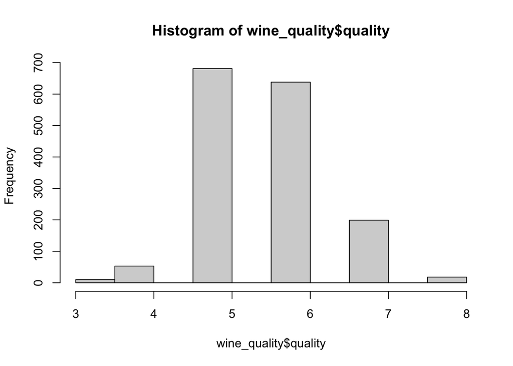

```r
 # Visualize the distribution of the target variable (quality)
 hist(wine_quality$quality)
```

**4. Unsupervised Learning Task (“Wholesale Customers”)**

*Identify homogeneous population groups and dimension reduction techniques for “wholesale customer” dataset. We decided to exclude “Channel” and “Region”, as categorical variabels may not work well on distance based algorithms.*

**4a. K-Means Clustering**

*Conduct K-Means to divide dataset into K clusters with the nearest means. First, we need to identify the number of K. We will use “The Elbow Method”.*

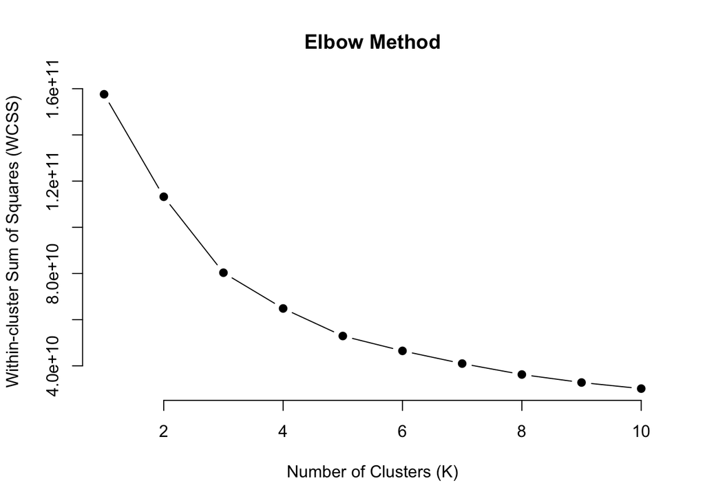

```r
# Remove 'Channel' and 'Region' variables from the dataset
wholesale_data_without_cat <- wholesale_data[, !(names(wholesale_data) %in% c("Channel", "Region"))]

# Compute the within-cluster sum of squares (WCSS) for different values of K
wcss <- vector()
for (i in 1:10) {
  kmeans_model <- kmeans(wholesale_data_without_cat, centers = i, nstart = 10)
  wcss[i] <- kmeans_model$tot.withinss
}

# Plot the elbow method graph
plot(1:10, wcss, type = 'b', pch = 19, frame = FALSE, xlab = 'Number of Clusters (K)', ylab = 'Within-cluster Sum of Squares (WCSS)', main = 'Elbow Method')
```

```r
# Fit K-means model with k=5
kmeans_model <- kmeans(wholesale_data_without_cat, centers = 5, nstart = 10)

# Get cluster assignments for each observation
cluster_assignments <- kmeans_model$cluster

# View the cluster centers
cluster_centers <- kmeans_model$centers
print(cluster_centers)
```

```
##       Fresh      Milk   Grocery    Frozen Detergents_Paper Delicassen
## 1 56453.308 10026.231  8739.000 15518.077         1258.231  7170.5385
## 2 20031.286 38084.000 56126.143  2564.571        27644.571  2548.1429
## 3  4991.481 12140.543 18505.506  1591.111         8148.247  1822.4074
## 4 23710.849  3882.057  5169.311  3772.443         1118.264  1693.1038
## 5  6387.807  3255.562  4056.562  2588.858         1199.330   999.1631
```

*Average spending across clusters*

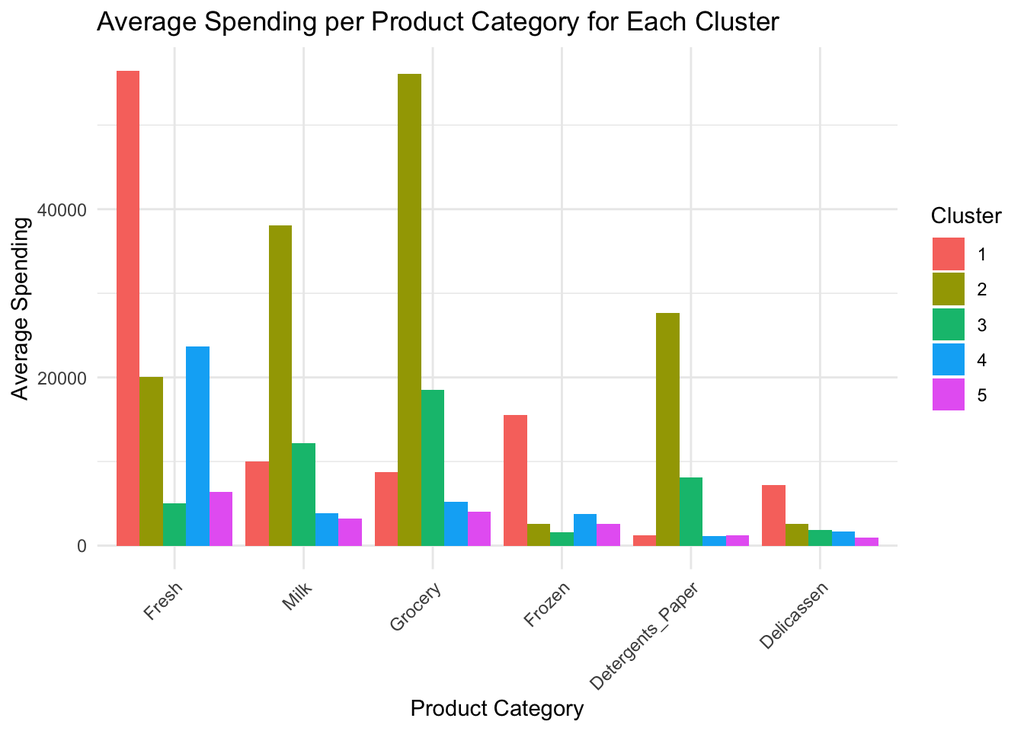

```r
# Calculate average spending for each product category within each cluster
avg_spending <- aggregate(wholesale_data_without_cat, by = list(Cluster = cluster_assignments), FUN = mean)

# Reshape the data for plotting
library(reshape2)
melted_data <- melt(avg_spending, id.vars = "Cluster")

# Plot the bar plot
library(ggplot2)
ggplot(melted_data, aes(x = variable, y = value, fill = factor(Cluster))) +
  geom_bar(stat = "identity", position = "dodge") +
  labs(x = "Product Category", y = "Average Spending", fill = "Cluster") +
  ggtitle("Average Spending per Product Category for Each Cluster") +
  theme_minimal() +
  theme(axis.text.x = element_text(angle = 45, hjust = 1))
```

**4b. Principal Component Analysis**

*Let’s conduct PCA, where we will use a scree plot to decide on the number of PC*

```r
# Perform PCA
pca_result <- prcomp(wholesale_data[, -c(1, 2)], scale. = TRUE)

# Summary of PCA results
summary(pca_result)
```

```
## Importance of components:
##                           PC1    PC2    PC3     PC4     PC5    PC6
## Standard deviation     1.6263 1.3048 0.8603 0.75082 0.53449 0.2509
## Proportion of Variance 0.4408 0.2838 0.1233 0.09396 0.04761 0.0105
## Cumulative Proportion  0.4408 0.7246 0.8479 0.94189 0.98950 1.0000
```

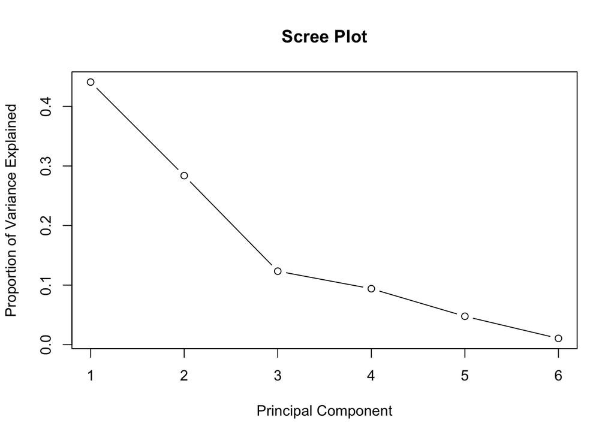

```r
# Scree plot
plot(1:length(pca_result$sdev), pca_result$sdev^2 / sum(pca_result$sdev^2), type = "b",
     xlab = "Principal Component", ylab = "Proportion of Variance Explained",
     main = "Scree Plot")
```

*By the elbow point we dicde to choose PCA with 4 PC*

```r
# Perform PCA with 4 principal components
num_pcs <- 4
pca_result <- prcomp(wholesale_data[, -c(1, 2)], scale. = TRUE, rank = num_pcs)

# Summary of PCA results
summary(pca_result)
```

```
## Importance of first k=4 (out of 6) components:
##                           PC1    PC2    PC3     PC4
## Standard deviation     1.6263 1.3048 0.8603 0.75082
## Proportion of Variance 0.4408 0.2838 0.1233 0.09396
## Cumulative Proportion  0.4408 0.7246 0.8479 0.94189
```

*Here is a Biplot*

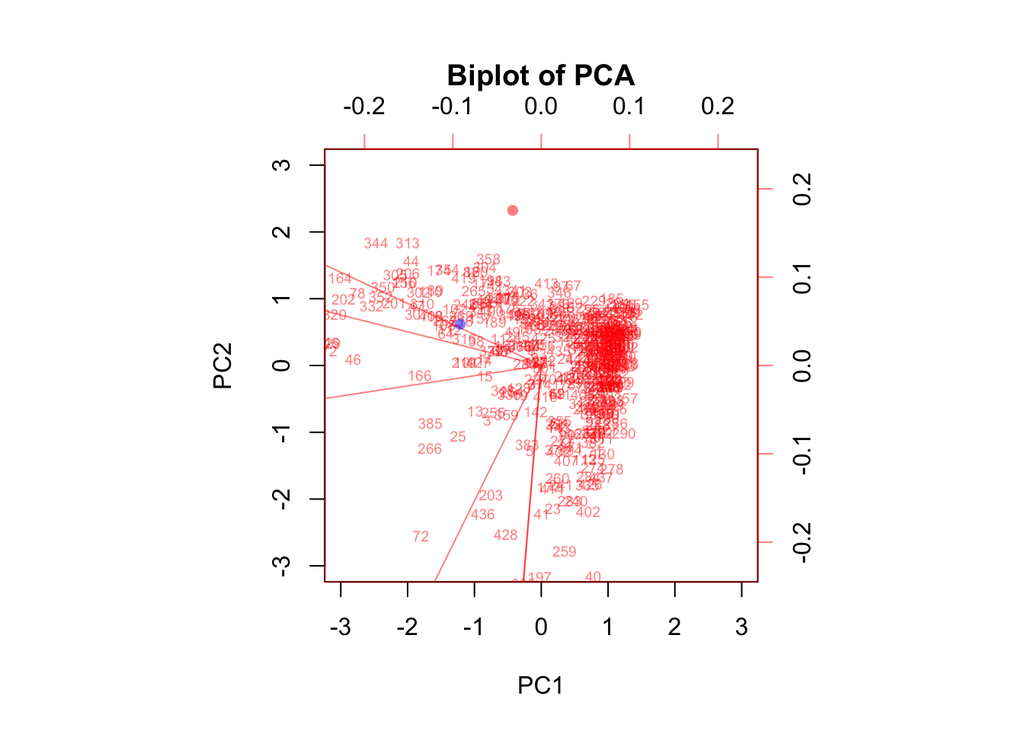

```r
# Create a better biplot with "PC1" and "PC2" labels
biplot(pca_result, scale = 0, cex = 0.6, col = alpha(c("blue", "red")[wholesale_data$Channel], 0.5),
       main = "Biplot of PCA", xlim = c(-3, 3), ylim = c(-3, 3), xlab = "PC1", ylab = "PC2")

# Add labels for variables (selecting a subset)
selected_vars <- c("Fresh", "Milk", "Grocery", "Frozen", "Detergents_Paper", "Delicassen")
text(pca_result$rotation[rownames(pca_result$rotation) %in% selected_vars, 1:2],
     labels = rownames(pca_result$rotation)[rownames(pca_result$rotation) %in% selected_vars],
     pos = 3, cex = 0.7, col = "darkgreen")

# Plot a random sample of data points
set.seed(123)  # For reproducibility
sample_size <- 100  # Adjust as needed
sample_indices <- sample(1:nrow(wholesale_data), sample_size)
points(pca_result$x[sample_indices, 1], pca_result$x[sample_indices, 2],
       col = alpha(c("blue", "red")[wholesale_data$Channel[sample_indices]], 0.5), pch = 16)
```

*Here is the distribution of customers on the first 2 PC*

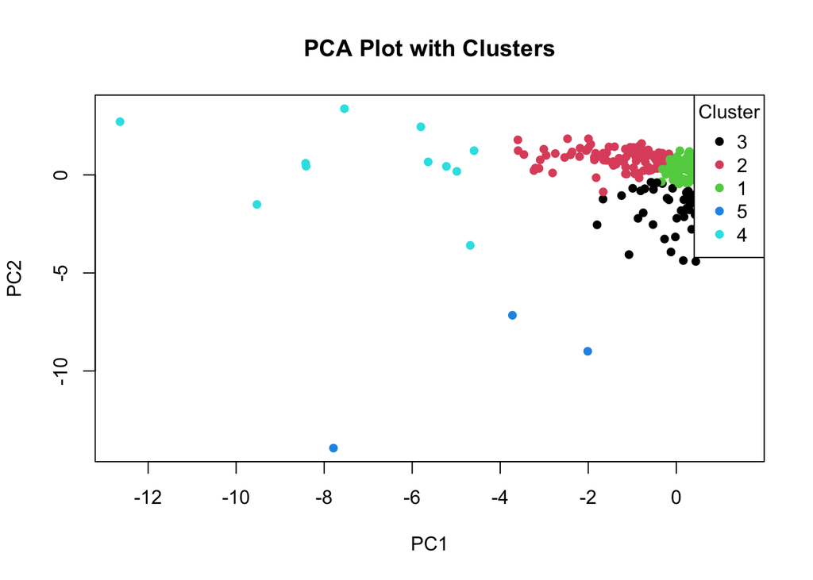

```r
# Perform PCA with 4 principal components
pca_result <- prcomp(wholesale_data[, -c(1, 2)], scale. = TRUE, rank = 4)

# Perform K-means clustering on the first two principal components
kmeans_result <- kmeans(pca_result$x[, 1:2], centers = 5)
cluster_assignments <- kmeans_result$cluster

# Plot PCA of customer segments with colors representing clusters
plot(pca_result$x[, 1], pca_result$x[, 2], col = cluster_assignments,
     pch = 16, xlab = "PC1", ylab = "PC2", main = "PCA Plot with Clusters")

# Add legend
legend("topright", legend = unique(cluster_assignments), col = 1:max(cluster_assignments), pch = 16, title = "Cluster")
```

```r
{# Calculate the proportion of variance explained by each principal component
prop_var <- pca_result$sdev^2 / sum(pca_result$sdev^2)
}
```

*Model Assessment*

```r
# Create a table to display proportions of variance explained by each principal component
var_table <- data.frame(
  Principal_Component = paste("PC", 1:length(prop_var)),
  Variance_Explained = prop_var
)

print(var_table)
```

```
##   Principal_Component Variance_Explained
## 1                PC 1         0.44082893
## 2                PC 2         0.28376400
## 3                PC 3         0.12334413
## 4                PC 4         0.09395504
## 5                PC 5         0.04761272
## 6                PC 6         0.01049519
```

**5. Regression Task (“Real Estate Valuation”)**

**5a. Linear Regression**

*The correlation of the coefficients with “Y house price of unit area” to indicate the strength of the linear relationship between variables.*

```r
# Load required library for correlation visualization
library(corrplot)
# Calculate correlation coefficients with Y house price of unit area
correlation_with_price <- cor(real_estate_data[, -1], real_estate_data$`Y house price of unit area`)

# Print correlation coefficients
print(correlation_with_price)
```

```
##                                               [,1]
## X1 transaction date                     0.08752927
## X2 house age                           -0.21056705
## X3 distance to the nearest MRT station -0.67361286
## X4 number of convenience stores         0.57100491
## X5 latitude                             0.54630665
## X6 longitude                            0.52328651
## Y house price of unit area              1.00000000
```

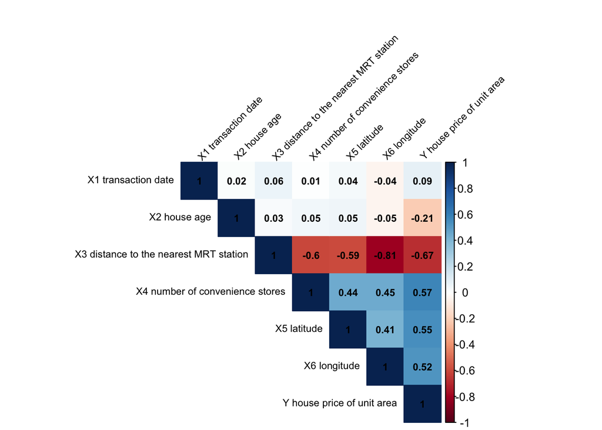

```r
# Calculate correlation matrix including Y house price of unit area
correlation_matrix <- cor(real_estate_data[, -1])

# Visualize correlation matrix as a heatmap with larger plot size
corrplot(correlation_matrix, method = "color", type = "upper", tl.col = "black", tl.srt = 45, tl.cex = 0.7, addCoef.col = "black", number.cex = 0.7, mar = c(0,0,2,0))
```

*Checking Variance Inflation Factor in case of “multicollinearity”.*

```r
# Load required library for VIF calculation
library(car)
# Check for multicollinearity using VIFs
vif_results <- vif(lm(`Y house price of unit area` ~ ., data = real_estate_data))
print(vif_results)
```

```
##                                       No
##                                 1.005870
##                    `X1 transaction date`
##                                 1.016603
##                           `X2 house age`
##                                 1.015215
## `X3 distance to the nearest MRT station`
##                                 4.332612
##        `X4 number of convenience stores`
##                                 1.617776
##                            `X5 latitude`
##                                 1.610762
##                           `X6 longitude`
##                                 2.931430
```

*Performing “Linear Regression” technique by dividing data into training and test sets.*

```r
# Load required library
library(caret)
# Set seed for reproducibility
set.seed(123)

# Split the dataset into 80% training and 20% test sets
train_index <- createDataPartition(real_estate_data$`Y house price of unit area`, p = 0.8, list = FALSE)
train_data <- real_estate_data[train_index, ]
test_data <- real_estate_data[-train_index, ]

# Fit a linear regression model using the training data
lm_model <- lm(`Y house price of unit area` ~ ., data = train_data)

# Make predictions on the test data
predictions <- predict(lm_model, newdata = test_data)

# Evaluate the model's performance
mse <- mean((test_data$`Y house price of unit area` - predictions)^2)
rmse <- sqrt(mse)
print(paste("Root Mean Squared Error (RMSE):", rmse))
```

```
## [1] "Root Mean Squared Error (RMSE): 7.78379778126903"
```

```r
# Summary of the linear regression model
summary(lm_model)
```

```
##
## Call:
## lm(formula = `Y house price of unit area` ~ ., data = train_data)
##
## Residuals:
##     Min      1Q  Median      3Q     Max
## -36.058  -5.158  -0.851   3.966  74.739
##
## Coefficients:
##                                            Estimate Std. Error t value Pr(>|t|)
## (Intercept)                              -1.332e+04  7.648e+03  -1.741  0.08262
## No                                       -2.425e-03  4.193e-03  -0.578  0.56350
## `X1 transaction date`                     5.674e+00  1.799e+00   3.155  0.00176
## `X2 house age`                           -2.697e-01  4.496e-02  -5.999 5.31e-09
## `X3 distance to the nearest MRT station` -4.749e-03  7.991e-04  -5.943 7.22e-09
## `X4 number of convenience stores`         1.134e+00  2.140e-01   5.298 2.17e-07
## `X5 latitude`                             2.440e+02  4.964e+01   4.916 1.41e-06
## `X6 longitude`                           -3.419e+01  5.501e+01  -0.621  0.53472
##
## (Intercept)                              .
## No
## `X1 transaction date`                    **
## `X2 house age`                           ***
## `X3 distance to the nearest MRT station` ***
## `X4 number of convenience stores`        ***
## `X5 latitude`                            ***
## `X6 longitude`
## ---
## Signif. codes:  0 '***' 0.001 '**' 0.01 '*' 0.05 '.' 0.1 ' ' 1
##
## Residual standard error: 9.122 on 324 degrees of freedom
## Multiple R-squared:   0.58,  Adjusted R-squared:  0.571
## F-statistic: 63.93 on 7 and 324 DF,  p-value: < 2.2e-16
```

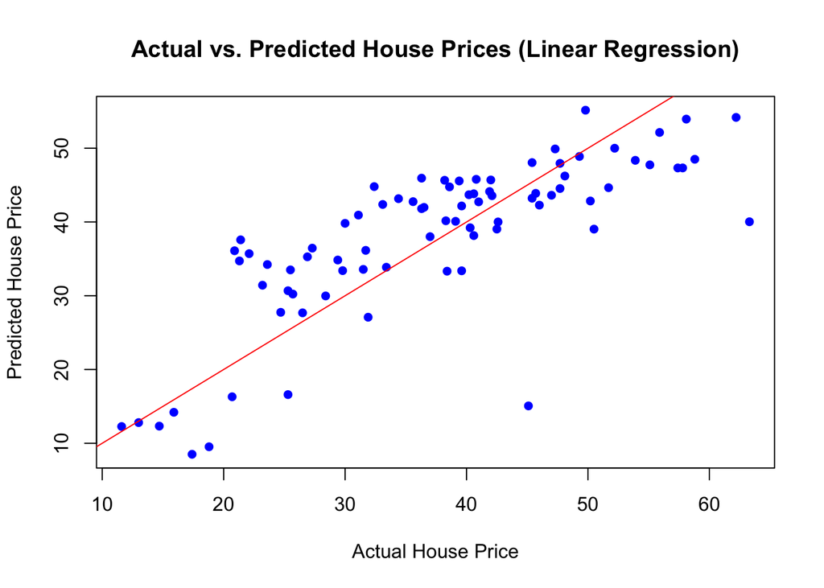

```r
# Create a scatter plot of actual vs. predicted house prices
plot(test_data$`Y house price of unit area`, predictions,
     main = "Actual vs. Predicted House Prices (Linear Regression)",
     xlab = "Actual House Price",
     ylab = "Predicted House Price",
     col = "blue",
     pch = 16)

# Add a diagonal line for reference
abline(0, 1, col = "red")
```

**5b. Random Forest**

*Performing “Random Forest” technique, by dividing data into training and test sets as the opposite to “Linear Regression” to capture nonlinear relationship.*

```r
# Load the randomForest package
library(randomForest)
# Split the data into features (X) and target variable (Y)
X <- real_estate_data[, -1]  # Exclude 'No' column
Y <- real_estate_data$`Y house price of unit area`

# Split data into training and testing sets (80% training data)
set.seed(123)  # for reproducibility
train_index <- sample(1:nrow(X), 0.8 * nrow(X))  # 80% training data
X_train <- X[train_index, ]
Y_train <- Y[train_index]
X_test <- X[-train_index, ]
Y_test <- Y[-train_index]

# Train the random forest regression model
rf_model <- randomForest(x = X_train, y = Y_train)

# Predict the target variable for the test dataset
Y_pred <- predict(rf_model, newdata = X_test)

# Calculate RMSE
rmse <- sqrt(mean((Y_pred - Y_test)^2))
print(paste("Root Mean Squared Error (RF):", rmse))
```

```
## [1] "Root Mean Squared Error (RF): 2.20670981444569"
```

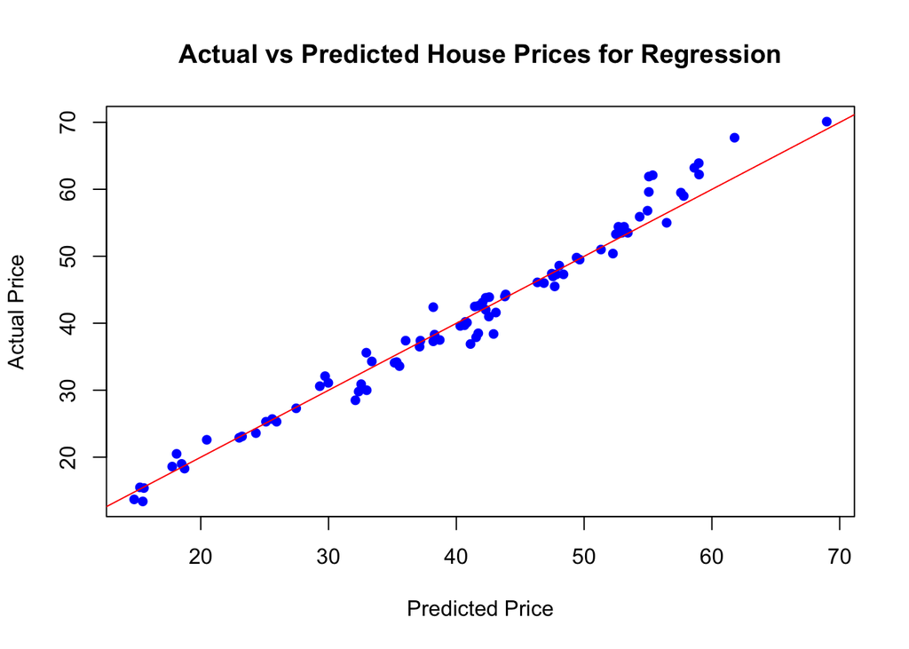

```r
# Visualize actual vs predicted house prices for regression
plot(Y_pred, Y_test,
     xlab = "Predicted Price",
     ylab = "Actual Price",
     main = "Actual vs Predicted House Prices for Regression",
     pch = 16, col = "blue")
abline(0, 1, col = "red")
```

*Visualization of “Feature Importance”.*

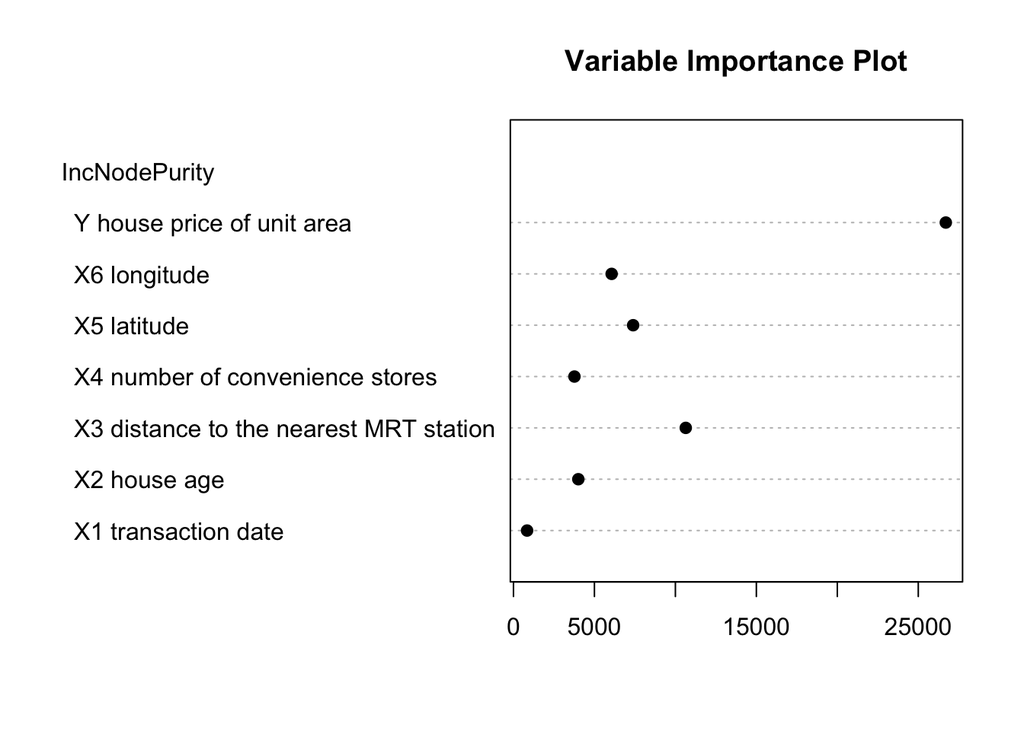

```r
# Train the random forest regression model
rf_model <- randomForest(x = X_train, y = Y_train)

# Calculate variable importance
var_importance <- importance(rf_model)

# Create a dot plot for variable importance
dotchart(var_importance, main = "Variable Importance Plot", col = "black", pch = 19)
```

**6. Classification Task (“Red Wine Quality”)**

*Utilize classification techniques to investigate, quantify, and predict the relationship between “chemical properties of wine” and “wine quality categories”*

**6a. Multinomial Logistic Regression**

*Performing “Multinomial Logistic Regression” technique by dividing data into training and test sets, and dividing “quality” into 4 classes:“Poor”, “Fair”, “Good”, “Excellent”. Evaluate the prediction.*

```r
# Set seed for reproducibility
set.seed(123)

# Create indices for training and test sets
train_indices <- createDataPartition(wine_quality$quality, p = 0.8, list = FALSE)

# Split data into training and test sets
train_data <- wine_quality[train_indices, ]
test_data <- wine_quality[-train_indices, ]

# Convert 'quality' into a factor with 4 levels for both training and test sets
train_data$quality <- cut(train_data$quality, breaks = 4, labels = c("Poor", "Fair", "Good", "Excellent"))
test_data$quality <- cut(test_data$quality, breaks = 4, labels = c("Poor", "Fair", "Good", "Excellent"))
# Load required libraries
library(nnet)
library(caret)

# Train multinomial logistic regression model
multinom_model <- multinom(quality ~ ., data = train_data)
# Make predictions on test data
predictions <- predict(multinom_model, newdata = test_data)

# Evaluate model performance
confusion_matrix <- confusionMatrix(predictions, test_data$quality)
accuracy <- confusion_matrix$overall['Accuracy']

# Print evaluation metrics
print(paste("Accuracy:", accuracy))
```

```
## [1] "Accuracy: 0.610062893081761"
```

```r
print(confusion_matrix)
```

```
## Confusion Matrix and Statistics
##
##            Reference
## Prediction  Poor Fair Good Excellent
##   Poor         0    0    0         0
##   Fair         8  105   41         0
##   Good         5   27   74        28
##   Excellent    1    2   12        15
##
## Overall Statistics
##
##                Accuracy : 0.6101
##                  95% CI : (0.5541, 0.664)
##     No Information Rate : 0.4214
##     P-Value [Acc > NIR] : 1.012e-11
##
##                   Kappa : 0.3658
##
##  Mcnemar's Test P-Value : 0.0003027
##
## Statistics by Class:
##
##                      Class: Poor Class: Fair Class: Good Class: Excellent
## Sensitivity              0.00000      0.7836      0.5827          0.34884
## Specificity              1.00000      0.7337      0.6859          0.94545
## Pos Pred Value               NaN      0.6818      0.5522          0.50000
## Neg Pred Value           0.95597      0.8232      0.7120          0.90278
## Prevalence               0.04403      0.4214      0.3994          0.13522
## Detection Rate           0.00000      0.3302      0.2327          0.04717
## Detection Prevalence     0.00000      0.4843      0.4214          0.09434
## Balanced Accuracy        0.50000      0.7586      0.6343          0.64715
```

*Confusion Matrix*

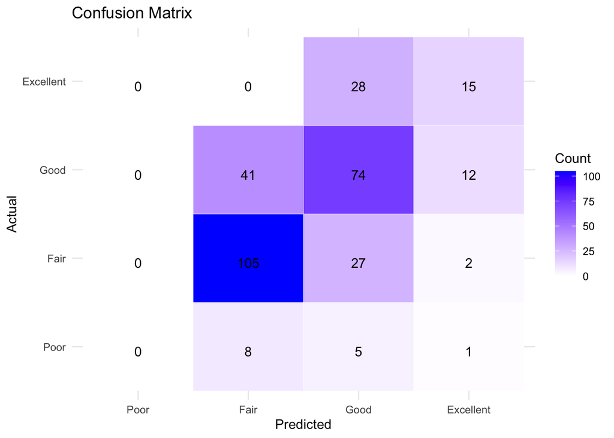

```r
 library(ggplot2)

 # Convert confusion matrix to a data frame
 confusion_df <- as.data.frame(confusion_matrix$table)

 # Rename columns for better visualization
 colnames(confusion_df) <- c("Predicted", "Actual", "Count")

 # Create confusion matrix plot
 confusion_plot <- ggplot(confusion_df, aes(x = Predicted, y = Actual, fill = Count)) +
   geom_tile(color = "white") +
   geom_text(aes(label = Count), vjust = 1) +
   scale_fill_gradient(low = "white", high = "blue") +  # Adjust color scale as needed
   labs(title = "Confusion Matrix",
        x = "Predicted",
        y = "Actual") +
   theme_minimal()

 # Print the plot
 print(confusion_plot)
```

*Precision-Recall Curve*

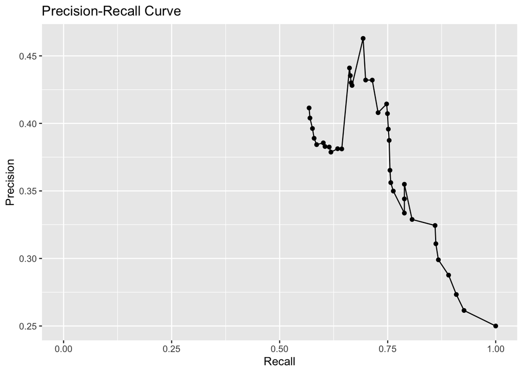

```r
# Assuming multinom_model is your multinomial logistic regression model

# Make predictions on test data to obtain predicted probabilities for each class
probabilities <- predict(multinom_model, newdata = test_data, type = "probs")

# Calculate precision, recall, and thresholds for each class
precision <- numeric()
recall <- numeric()
thresholds <- seq(0, 1, by = 0.01)

for (threshold in thresholds) {
  # Convert predicted probabilities to binary predictions based on threshold
  binary_predictions <- apply(probabilities, 2, function(x) ifelse(x >= threshold, 1, 0))

  # Calculate precision and recall for each class
  class_precision <- c()
  class_recall <- c()
  for (i in 1:ncol(binary_predictions)) {
    tp <- sum(binary_predictions[, i] == 1 & test_data$quality == levels(test_data$quality)[i])
    fp <- sum(binary_predictions[, i] == 1 & test_data$quality != levels(test_data$quality)[i])
    fn <- sum(binary_predictions[, i] == 0 & test_data$quality == levels(test_data$quality)[i])
    class_precision[i] <- tp / (tp + fp)
    class_recall[i] <- tp / (tp + fn)
  }

  # Take the mean precision and recall across all classes
  precision <- c(precision, mean(class_precision))
  recall <- c(recall, mean(class_recall))
}

# Plot Precision-Recall curve
library(ggplot2)
df <- data.frame(thresholds, precision, recall)
ggplot(df, aes(x = recall, y = precision)) +
  geom_line() +
  geom_point() +
  labs(x = "Recall", y = "Precision", title = "Precision-Recall Curve")
```

**6b. K-Nearest Neighbors**

*Performing “K-Nearest Neighbor” technique by dividing data into training and test sets, and dividing “quality” into 4 classes:“Poor”, “Fair”, “Good”, “Excellent”. Evaluate the prediction.*

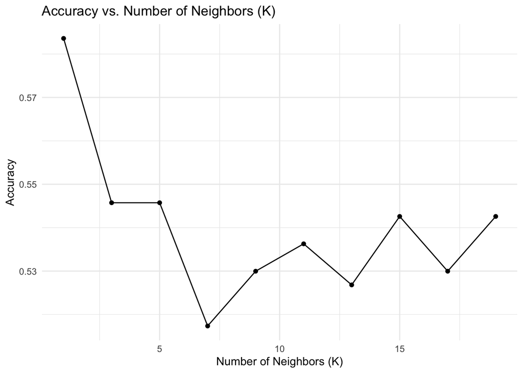

```r
library(class)
library(caret)
library(ggplot2)

# Preprocess the data: Convert quality to categorical classes
wine_quality$quality_class <- cut(wine_quality$quality, breaks = c(0, 5, 6, 7, 10),
                                  labels = c("Poor", "Fair", "Good", "Excellent"))

# Split data into training and testing sets (80% training, 20% testing)
set.seed(123)  # for reproducibility
train_indices <- createDataPartition(wine_quality$quality_class, p = 0.8, list = FALSE)
train_data <- wine_quality[train_indices, ]
test_data <- wine_quality[-train_indices, ]

# Define a range of k values to try
k_values <- seq(1, 20, by = 2)

# Initialize vectors to store accuracy values for each k
accuracy_values <- vector()

# Iterate over each k value
for (k in k_values) {
  # Train KNN classifier
  knn_model <- knn(train = train_data[, -c(12, 13)], test = test_data[, -c(12, 13)],
                   cl = train_data$quality_class, k = k)

  # Evaluate performance
  accuracy <- mean(knn_model == test_data$quality_class)
  accuracy_values <- c(accuracy_values, accuracy)
}

# Visualize the results
results <- data.frame(k = k_values, accuracy = accuracy_values)
ggplot(results, aes(x = k, y = accuracy)) +
  geom_line() +
  geom_point() +
  labs(title = "Accuracy vs. Number of Neighbors (K)",
       x = "Number of Neighbors (K)", y = "Accuracy") +
  theme_minimal()
```

```r
# Load required libraries
library(class)
library(caret)
library(ggplot2)

# Preprocess the data: Convert quality to categorical classes
wine_quality$quality_class <- cut(wine_quality$quality, breaks = c(0, 5, 6, 7, 10),
                                  labels = c("Poor", "Fair", "Good", "Excellent"))

# Split data into training and testing sets (80% training, 20% testing)
set.seed(123)  # for reproducibility
train_indices <- createDataPartition(wine_quality$quality_class, p = 0.8, list = FALSE)
train_data <- wine_quality[train_indices, ]
test_data <- wine_quality[-train_indices, ]

# Train KNN classifier
k <- 5  # Number of neighbors
knn_model <- knn(train = train_data[, -c(12, 13)], test = test_data[, -c(12, 13)],
                 cl = train_data$quality_class, k = k)

# Evaluate performance
accuracy <- mean(knn_model == test_data$quality_class)
cat("Accuracy of KNN classifier:", accuracy, "\n")
```

```
## Accuracy of KNN classifier: 0.5425868
```

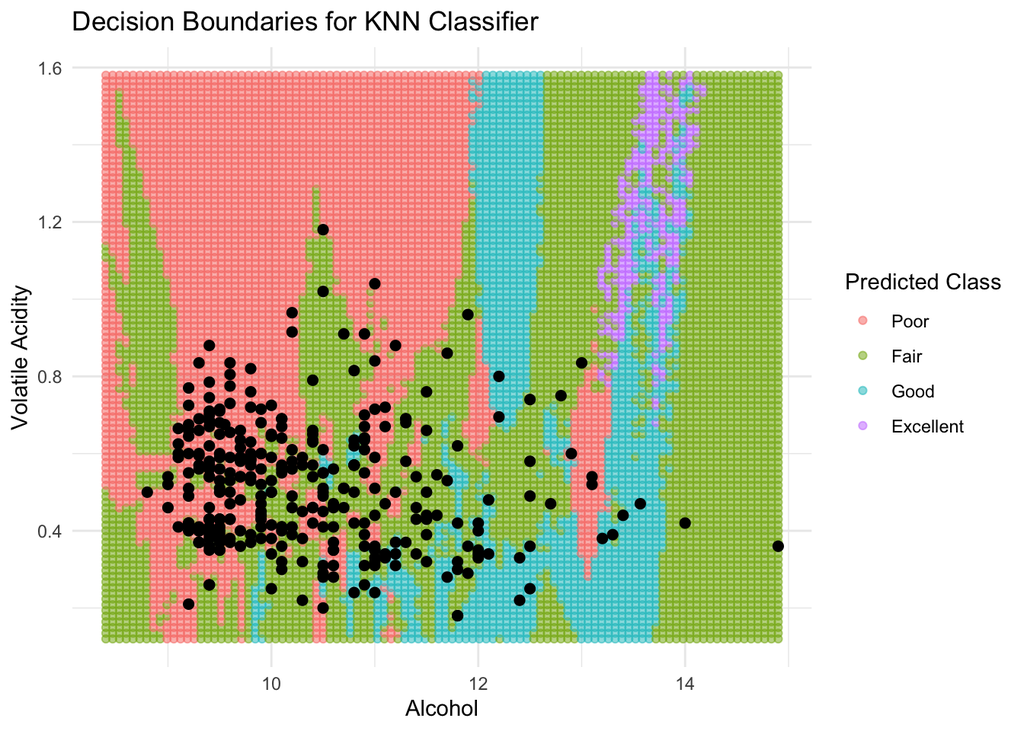

```r
# Visualize decision boundaries (for two selected features)
feature1 <- "alcohol"
feature2 <- "volatile.acidity"

# Create a grid of points to predict
x1 <- seq(min(wine_quality[[feature1]]), max(wine_quality[[feature1]]), length.out = 100)
x2 <- seq(min(wine_quality[[feature2]]), max(wine_quality[[feature2]]), length.out = 100)
grid <- expand.grid(alcohol = x1, volatile.acidity = x2)

# Predict classes for the grid points
grid$predicted_class <- knn(train = train_data[, c(feature1, feature2)],
                            test = grid, cl = train_data$quality_class, k = k)

# Plot the decision boundaries
ggplot(data = grid, aes(x = alcohol, y = volatile.acidity, color = predicted_class)) +
  geom_point(alpha = 0.5) +
  geom_point(data = test_data, aes(x = alcohol, y = volatile.acidity), color = "black", size = 2) +
  labs(title = "Decision Boundaries for KNN Classifier",
       x = "Alcohol", y = "Volatile Acidity", color = "Predicted Class") +
  theme_minimal()
```

*Let’s see the hierarchy of contribution of each feature to classification*

```r
library(caret)
knn_model_with_importance <- train(train_data[, -c(12, 13)], train_data$quality_class,
                                   method = "knn", trControl = trainControl(method = "cv"))
varImp(knn_model_with_importance)
```

```
## ROC curve variable importance
##
##   variables are sorted by maximum importance across the classes
##                         Poor   Fair   Good Excellent
## alcohol              94.2053 100.00 52.957    100.00
## sulphates            65.2254  85.61 34.695     85.61
## volatile.acidity     70.5077  67.73 36.560     70.51
## chlorides            28.9426  59.06 12.716     59.06
## citric.acid          44.4864  51.74 28.038     51.74
## density              30.4970  41.51 13.489     41.51
## total.sulfur.dioxide 34.3645  34.35 16.787     34.36
## fixed.acidity        23.6366  19.11 13.456     23.64
## pH                    0.0562  19.19  2.743     19.19
## free.sulfur.dioxide   9.7737  18.10  7.933     18.10
## residual.sugar       11.2490   0.00 13.418     11.25
```

*Let’s see the distribution of “actual” and “predicted” classes*

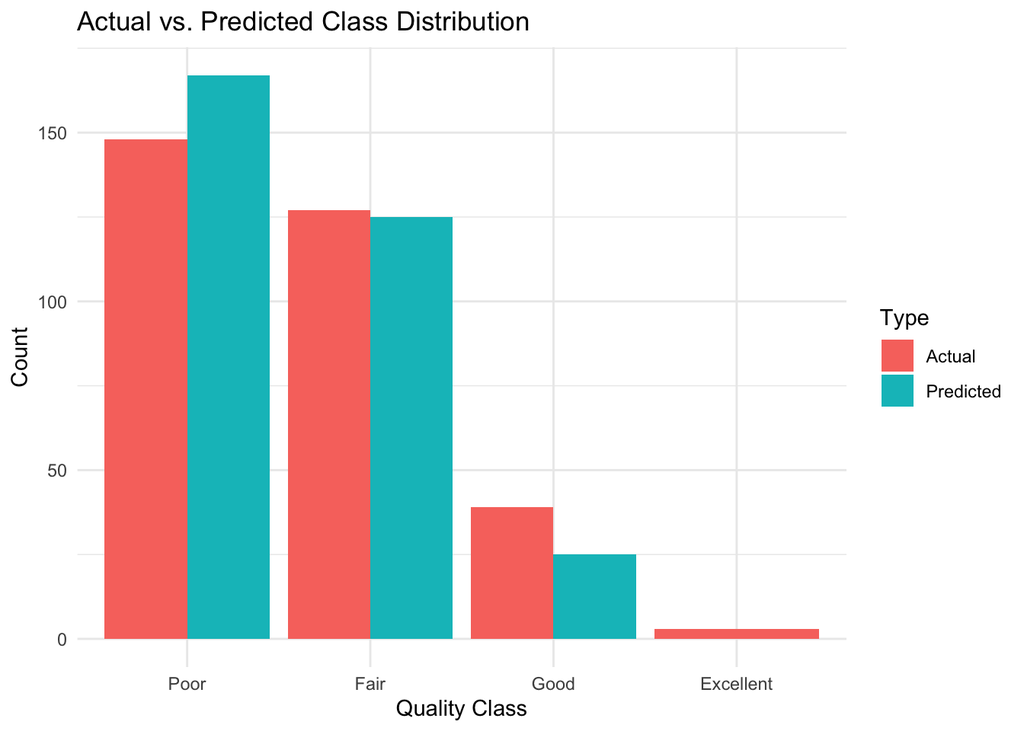

```r
# Combine actual and predicted classes into a single dataframe
class_comparison <- data.frame(Class = c(test_data$quality_class, knn_model),
                               Type = rep(c("Actual", "Predicted"), each = nrow(test_data)))

# Plot class distribution
ggplot(class_comparison, aes(x = Class, fill = Type)) +
  geom_bar(position = "dodge") +
  labs(title = "Actual vs. Predicted Class Distribution", x = "Quality Class", y = "Count") +
  theme_minimal()
```

**3. Conclusion**

1. For unsupervised learning:

The proportion of variance explained by PC is as follows:

PC1 explains approximately 44.08% of the variance.

PC2 explains approximately 28.38% of the variance.

PC3 explains approximately 12.33% of the variance.

PC4 explains approximately 9.40% of the variance.

PC5 explains approximately 4.76% of the variance.

PC6 explains approximately 1.05% of the variance.

2. For regression, RMSE(Random forest) = 2.21 < RMSE(Linear Regression) = 7.79. So we prefer Random forest.
3. For classification, Accuracy(KNN) = 0.54 < Accuracy(Multinomial Logit) = 0.61. So we prefer Multinomial logistic regression.